# Repeated Measurements in Clinical Studies Course

MEP-EL002 — Exam Group 4

Amanda Evelo, Anmol Rajpar, Maud van Drimmelen, Laura Verbeij

2026-04-07

# Exam introduction

You received a simulated database (each team has a different database) on patients who underwent valve transplantation in the aortic position from a human donor. After the operation, echocardiography measurements have been taken for these patients during a follow-up period of up to 20 years (note that some patients have a shorter follow-up, i.e., they have dropped out from the study, or some others may have missed some visits). The two outcomes we are primarily interested in here are the aortic gradient and the presence ot absence of aortic regurgitation. The database contains the following variables: • id: patient ID number • aoGrad: the value of aortic gradient (mmHg)* • aoReg: a {0, 1} variable denoting whether the patient had (value ‘1’) or not (value ‘0’) aortic regurgitation at the specific visit  
• times: time of the visit (years) • TypeOp: type of operation the patient underwent; possible values ‘A’ and ‘B’ • age: the age of the patients (years) • sex: the sex of the patients

# Part 1 of exam (continous data) - Aortic Gradient

```r
df <- load("Group_4.RData")
```

## Question 1

Start by producing summary statistics regarding the sample at hand (i.e., number of patients, number of males/females, number of patients per operation type, average age of patients, etc.).

```r
# Define variables
vars    <- c("Age", "sex", "aoGrad", "aoReg", "TypeOp", "time")
catVars <- c("sex", "TypeOp", "aoReg")

# Create TableOne object
tab1 <- CreateTableOne(
  vars       = vars,
  data       = DF,
  factorVars = catVars
)

tab1
```

```
##
##                      Overall
##   n                   4414
##   Age (mean (SD))    64.34 (13.56)
##   sex = female (%)    2110 (47.8)
##   aoGrad (mean (SD)) 17.74 (22.72)
##   aoReg = 1 (%)       1895 (42.9)
##   TypeOp = B (%)      2173 (49.2)
##   time (mean (SD))    8.74 (6.13)
```

## Question 2

First, the focus is on the aortic gradient outcome* (aoGrad). Produce descriptive figures for this outcome and graphically depict the longitudinal evolution (both marginal and subject-specific).

Discuss the results you obtain. Based on this descriptive analysis, do you see non-linearities, differences between operation types, and differences between younger and older patients? What does the distribution of the aortic gradient look like? Should you consider a transformation?

### Descriptives for primary outcome (aortic gradient)

The aortic (ventricle) gradient indicates the difference in pressure between the left ventricle and the aorta during heart contraction, it is often used to measure the severity of aortic stenosis.

Mean gradient (mmHg) classification for aortic stenosis (AS): Mild AS: 10-20 Moderate AS: 20–40 Severe AS: > 40 [source: https://pmc.ncbi.nlm.nih.gov/articles/PMC8503314/]

In this study, we want to observe differences in aortic gradients based on the type of operation patients received and start by visualizing this data in spaghetti plots. Starting with a general spaghetti plot for the *aortic gradient values over time*.

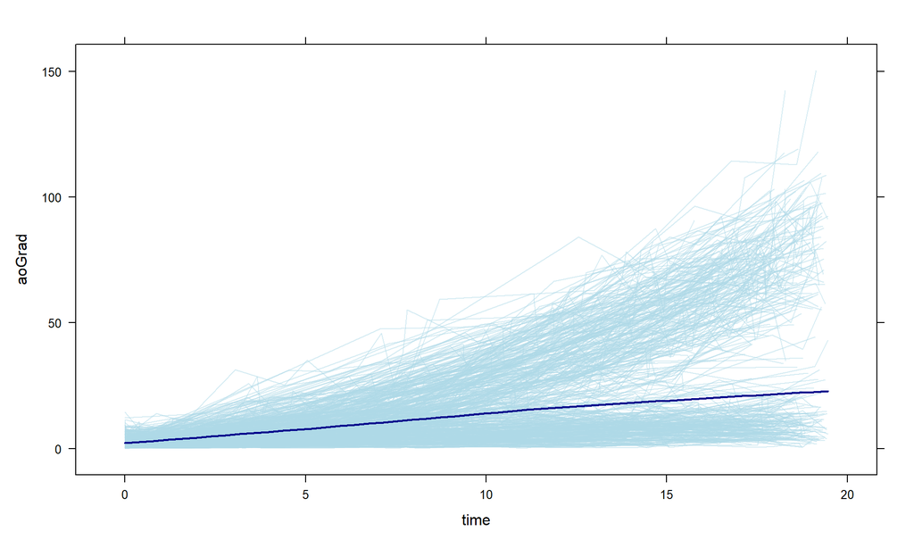

```r
# Spaghetti plot general
xyplot(aoGrad ~ time,
       data = DF,
       groups = id,
       type = "l",
       col = "lightblue",
       lwd = 1,
       alpha = 0.5,
       panel = function(x, y, ...)
         {
         panel.xyplot(x, y, ...)                      # spaghetti lines
         panel.loess(x, y, col = "darkblue", lwd = 2) # dark blue smoother
       })
```

*Observation aortic gradient values over time:* The spaghetti plot shows that patients begin with similar aortic gradient values early in follow‑up, but their trajectories separate clearly over time. The lines form two visually distinct bands, with very few observations falling between them, suggesting the presence of two dominant progression patterns even though no formal grouping was applied.

Then we split this spaghetti plot for *type of operation*.

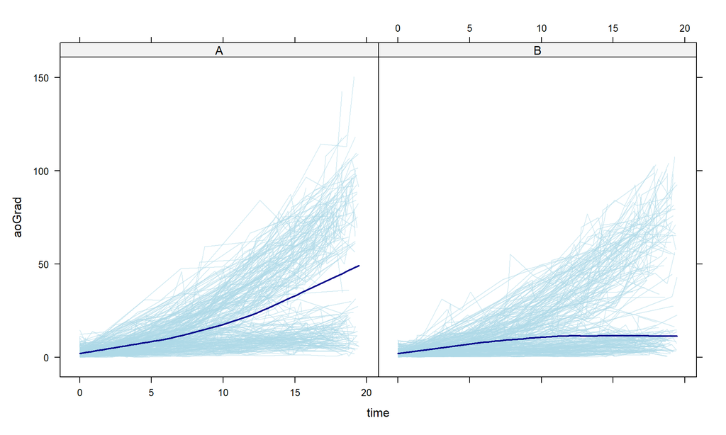

```r
# Spaghetti plot split for type of operation
xyplot(aoGrad ~ time | TypeOp,
       data = DF,
       groups = id,
       type = "l",
       col = "lightblue",
       lwd = 1,
       alpha = 0.5,
       panel = function(x, y, ...) {
         panel.xyplot(x, y, ...)                      # spaghetti lines
         panel.loess(x, y, col = "darkblue", lwd = 2) # dark blue smoother
       })
```

Specifically, a small number of patients that recieved oepration A seem to have elevated aortic gradient values at later follow‑up times (>100 mmHg). These high values indicate severe aortic stenosis at the end of the study and may reflect late complications, as described in previous studies. [source:https://pubmed.ncbi.nlm.nih.gov/20026771/].

When splitting for *biological sex* we see the following.

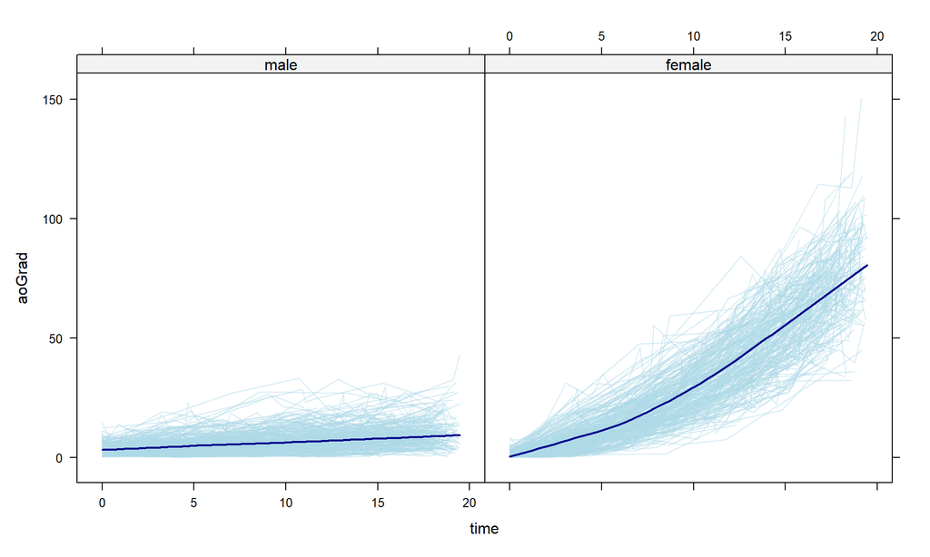

```r
# Spaghetti plot split for sex
xyplot(aoGrad ~ time | sex,
       data = DF,
       groups = id,
       type = "l",
       col = "lightblue",
       lwd = 1,
       alpha = 0.5,
       panel = function(x, y, ...) {
         panel.xyplot(x, y, ...)                      # spaghetti lines
         panel.loess(x, y, col = "darkblue", lwd = 2) # dark blue smoother
       })
```

The spaghetti plot shows clear differences between men and women, but appears very dense. Therefor using an xyplot with a smoothed trend line provides a clearer view of sex‑specific patterns.

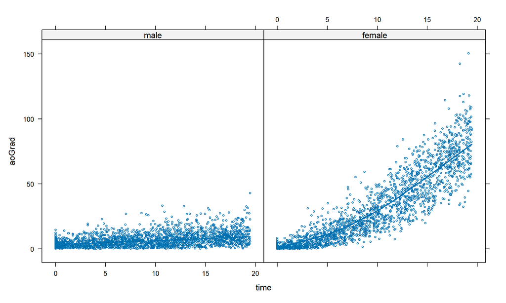

```r
# Aortic gradient evolution based on sex
xyplot(aoGrad~time | sex, data =DF, type=c("p", "smooth"), cex=0.5, lwd=2)
```

*Observation aortic gradient values over time divided biological sex:* Women show a stronger and more variable upward trend (dots are futher apart) in aortic gradient over time, whereas men show a flatter and more uniform pattern (dots are closer together).

Then looking at *age*, we did not use a spaghetti plot because age is a continuous variable, and the resulting lines would not represent meaningful trajectories.

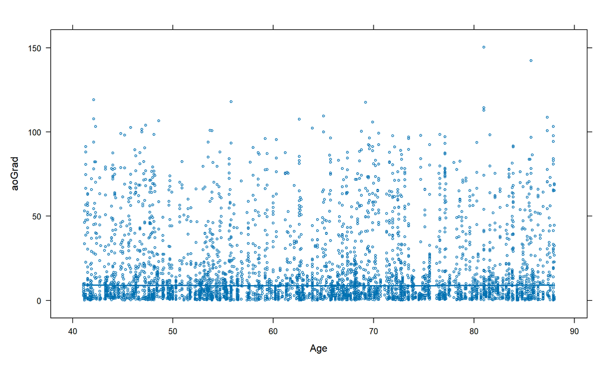

```r
xyplot(aoGrad ~ Age, data = DF, type = c("p", "smooth"), cex = 0.5, lwd = 2)
```

*Observation aortic gradient values per years of age:*  
Across the full age range, most points remain concentrated at low aortic‑gradient values, with no clear age‑related trend. This pattern is clinically possible, but it is unlikely that age has no effect at all, so we grouped age to explore whether broader categories would reveal differences. Grouping also allows us to visualise how the aortic gradient evolves over time within each age category.

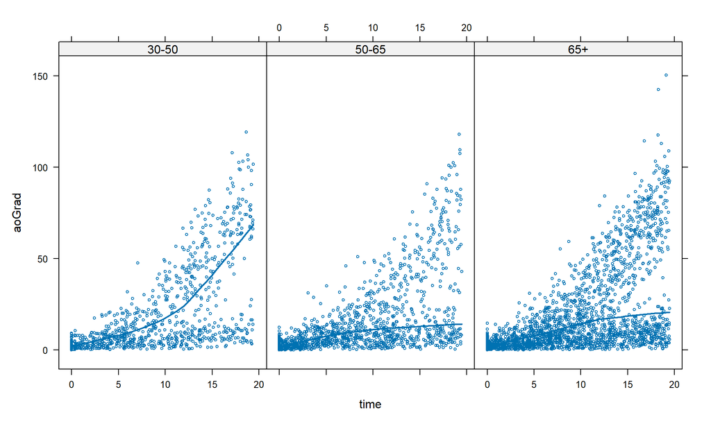

```r
# Making some age groups
DF$ageGroup <- cut(DF$Age,
                   breaks = c(0, 30, 50, 65, 120),
                   labels = c("<30", "30-50", "50-65", "65+"))

# Aortic gradient evolution based on these age groups
xyplot(aoGrad~time | ageGroup, data =DF, type=c("p", "smooth"), cex=0.5, lwd=2) #split by age groups
```

*Observation aortic gradient values over time for different age groups:* When age is grouped into three levels, both the point patterns and the LOESS curves suggest some age‑related differences. In particular, the 30–50 group shows a steeper LOESS‑based increase in aortic gradient over time.

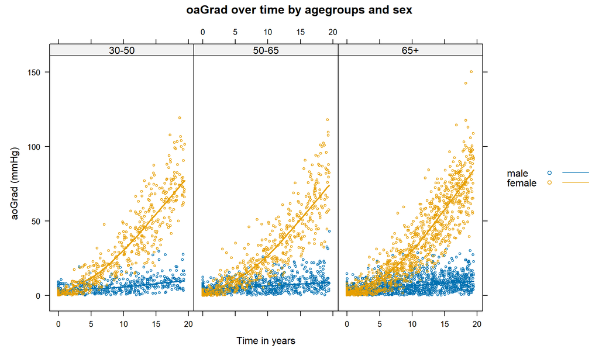

```r
# Aortic gradient evolution based on these age groups split by sex
xyplot(aoGrad ~ time | ageGroup, data =DF,
       groups = sex,
       type = c("p", "smooth"),
       cex =0.5, lwd=2,
       auto.key = list(space = "right"),
       main = "oaGrad over time by agegroups and sex",
       xlab = "Time in years",
       ylab = "aoGrad (mmHg)"
)
```

*Observation aortic gradient values over time for different age groups and sex highlighting:* When further dividing these age groups by sex, the sex effect observed in the overall population appears similar across all age categories.

Subsequently we looked further into the *aortic gradient over time split by age group and operation type*.

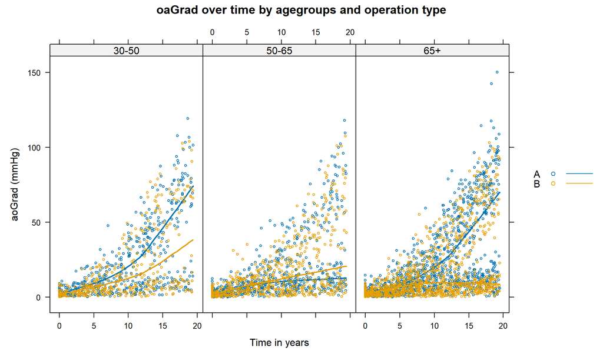

```r
# Aortic gradient evolution based on these age groups split by operation type
xyplot(aoGrad ~ time | ageGroup, data =DF,
       groups = TypeOp,
       type = c("p", "smooth"),
       cex =0.5, lwd=2,
       auto.key = list(space = "right"),
       main = "oaGrad over time by agegroups and operation type",
       xlab = "Time in years",
       ylab = "aoGrad (mmHg)"
)
```

*Observation aortic gradient values over time for different age groups and operation highlighting:* In this plot, the 50–65 group appears relatively stable over time, with little upward movement in the LOESS curve. In contrast, the 65+ group shows a much more divergent pattern toward the end of follow‑up. This is particularly visible in the large number of low aortic‑gradient observations among Type B operations (yellow points), whereas Type A operations (blue points) show a more consistent pattern.

### Distribution of primary outcome (auortic gradient)

We then evaluated the distributional characteristics of the main variable aortic gradient to inform the next modelling steps. we plotted a histogram with an overlaid density curve to assess its overall shape and spread.

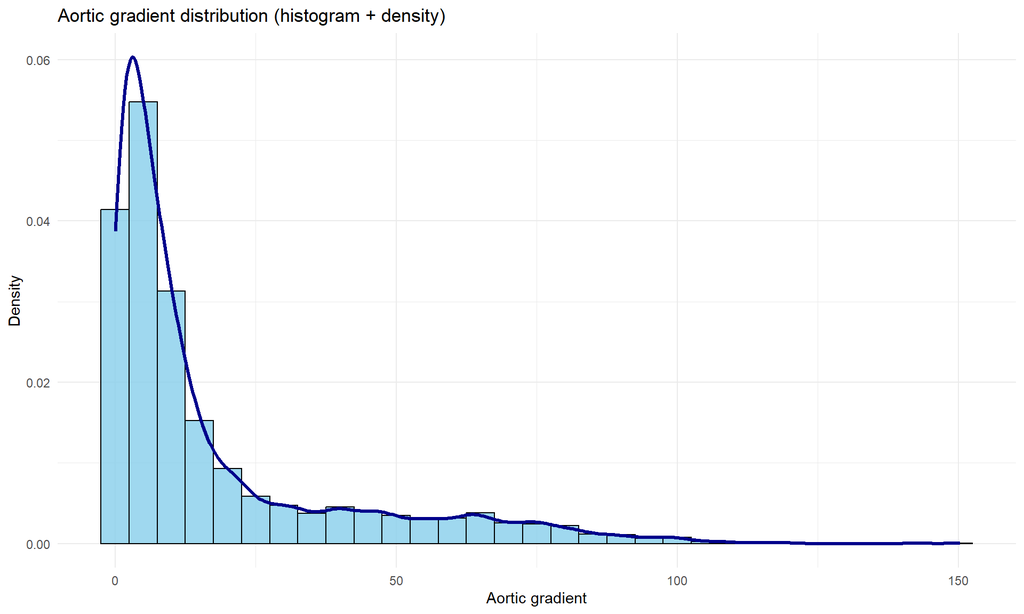

```r
# Histogram + Density bell curve plot
ggplot(DF, aes(x = aoGrad)) +
  geom_histogram(aes(y = after_stat(density)),
                 binwidth = 5, fill = "skyblue", color = "black", alpha = 0.8) +
  geom_density(color = "darkblue", lwd = 1.2) +
  labs(x = "Aortic gradient",
       y = "Density",
       title = "Aortic gradient distribution (histogram + density)") +
  theme_minimal()
```

A more suitable approach is therefore to *transform the aortic‑gradient variable*. Common options include a square‑root or logarithmic transformation. To determine which is most appropriate, we compare both transformations below.

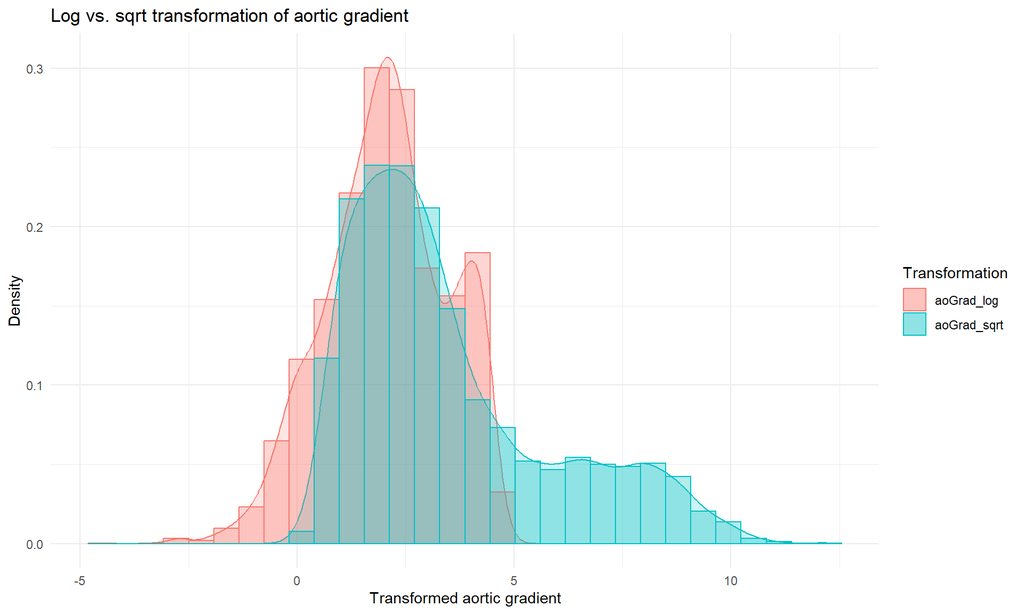

```r
# Trying a transformation on both log and sqrt options:
DF$aoGrad_log <- log(DF$aoGrad)
DF$aoGrad_sqrt <- sqrt(DF$aoGrad)

# Bell‑curve comparison (density plots)
# Stack both transformed versions with a label
df_long <- tidyr::pivot_longer(
  DF,
  cols = c(aoGrad_log, aoGrad_sqrt),
  names_to = "transf",
  values_to = "value"
)
# Actual plot
ggplot(df_long, aes(x = value, color = transf, fill = transf, alpha = after_scale(0.2))) +
  geom_density() +
  geom_histogram(aes(y = after_stat(density)),
                 alpha = 0.3, bins = 30, position = "identity") +
  labs(x = "Transformed aortic gradient",
       y = "Density",
       title = "Log vs. sqrt transformation of aortic gradient",
       color = "Transformation",
       fill = "Transformation") +
  theme_minimal()
```

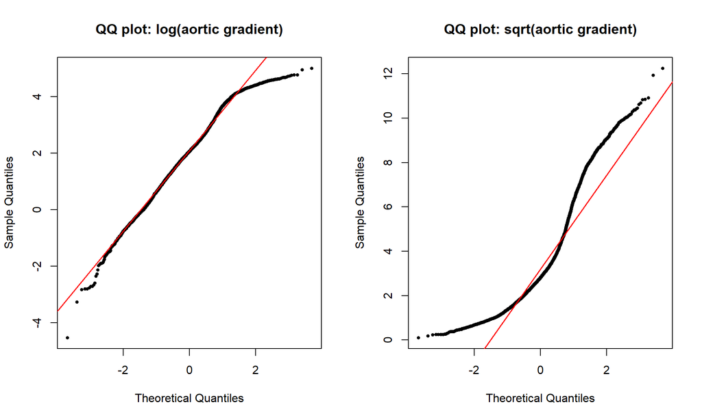

```r
# Stack both transformed variables
# 1) QQ plot for log‑transformed aoGrad
par(mfrow = c(1, 2))

qqnorm(DF$aoGrad_log,
       main = "QQ plot: log(aortic gradient)",
       pch = 16,
       cex = 0.6)
qqline(DF$aoGrad_log, col = "red", lwd = 1.5)

# 2) QQ plot for sqrt‑transformed aoGrad
qqnorm(DF$aoGrad_sqrt,
       main = "QQ plot: sqrt(aortic gradient)",
       pch = 16,
       cex = 0.6)
qqline(DF$aoGrad_sqrt, col = "red", lwd = 1.5)
```

```r
par(mfrow = c(1, 1))  # reset layout
```

*Observation of aortic gradient variable after transformation:* When comparing the log and square‑root transformations, both reduce the strong right‑skew of the original aortic‑gradient distribution. However, the histogram and density curves show that the log transformation produces a distribution that is more bell‑shaped and symmetric than the square‑root transformation. This is supported by the Q–Q plots, where the log‑transformed values follow the theoretical normal line more closely. Based on these distributional improvements, we will use the log‑transformed aortic‑gradient variable (aoGrad_log) for further analyses.

## Question 3 (Main Analysis)

The researchers in this study are interested in investigating how the aortic gradient evolves over time and how this evolution is related to the rest of the variables in the database (namely, age, sex, and type of operation).

Build an appropriate marginal model for the aortic gradient to answer this question. Describe all the steps you have performed to reach your final model (including the residuals analysis). For your final model, present the results you obtained in ‘simple words’ (i.e., such that a non‑statistician would understand – you may also use effect plots if deemed necessary).

### Step 1. building the marginal model

We start by building our marginal model using a basic generalized least squares estimation. This first model (fm0) does not yet include a correlation structure or variance function. At this stage, we specify only the mean structure and include all covariates of interest in the fixed‑effects part, considering possible nonlinear terms and interactions between them.

For the fixed effects, we model the non‑linear effects of time and age using natural cubic splines with three degrees of freedom. Following standard recommendations, we use the nsk() function, which places the boundary knots at the 5th and 95th percentiles of the follow‑up times. We also adjust for sex and type of operation, and include interactions between time and both sex and type of operation, as well as interactions between age and these same variables. Hence, the call to gls() that incorporates these components is:

```r
fm0 <- gls(aoGrad_log ~ nsk(time, 3) * (TypeOp + sex) + ns(Age, 3) +
             ns(Age, 3) : (TypeOp + sex), data = DF)

summary(fm0)
```

```
## Generalized least squares fit by REML
##   Model: aoGrad_log ~ nsk(time, 3) * (TypeOp + sex) + ns(Age, 3) + ns(Age,      3):(TypeOp + sex)
##   Data: DF
##        AIC      BIC    logLik
##   9926.734 10067.26 -4941.367
##
## Coefficients:
##                              Value  Std.Error  t-value p-value
## (Intercept)              0.8842858 0.08343975 10.59790  0.0000
## nsk(time, 3)1            0.4398756 0.06178959  7.11893  0.0000
## nsk(time, 3)2            0.9835742 0.05608621 17.53683  0.0000
## nsk(time, 3)3            1.2649601 0.06959951 18.17484  0.0000
## TypeOpB                 -0.1239548 0.09308740 -1.33160  0.1831
## sexfemale               -0.7720789 0.09329915 -8.27530  0.0000
## ns(Age, 3)1             -0.0459795 0.07834716 -0.58687  0.5573
## ns(Age, 3)2              0.3124831 0.18141645  1.72246  0.0851
## ns(Age, 3)3              0.1665496 0.07422358  2.24389  0.0249
## nsk(time, 3)1:TypeOpB    0.0544850 0.07258758  0.75061  0.4529
## nsk(time, 3)2:TypeOpB   -0.2568633 0.06564951 -3.91265  0.0001
## nsk(time, 3)3:TypeOpB   -0.0224937 0.08117041 -0.27712  0.7817
## nsk(time, 3)1:sexfemale  1.5606332 0.07272250 21.46011  0.0000
## nsk(time, 3)2:sexfemale  2.6608238 0.06576566 40.45917  0.0000
## nsk(time, 3)3:sexfemale  3.0651329 0.08113750 37.77702  0.0000
## TypeOpB:ns(Age, 3)1      0.1345729 0.09205717  1.46184  0.1439
## TypeOpB:ns(Age, 3)2     -0.1530739 0.19951795 -0.76722  0.4430
## TypeOpB:ns(Age, 3)3     -0.1082089 0.07906494 -1.36861  0.1712
## sexfemale:ns(Age, 3)1    0.0750252 0.09238170  0.81212  0.4168
## sexfemale:ns(Age, 3)2   -0.4634898 0.20046214 -2.31211  0.0208
## sexfemale:ns(Age, 3)3   -0.0916408 0.07957224 -1.15167  0.2495
##
##  Correlation:
##                         (Intr) ns(,3)1 ns(,3)2 ns(,3)3 TypOpB sexfml n(A,3)1
## nsk(time, 3)1           -0.419
## nsk(time, 3)2           -0.416  0.529
## nsk(time, 3)3           -0.370  0.591   0.427
## TypeOpB                 -0.578  0.260   0.259   0.235
## sexfemale               -0.662  0.248   0.244   0.218   0.114
## ns(Age, 3)1             -0.191 -0.012   0.014  -0.018   0.105  0.139
## ns(Age, 3)2             -0.816 -0.002   0.001   0.000   0.460  0.555  0.007
## ns(Age, 3)3             -0.209 -0.007  -0.005  -0.023   0.109  0.152 -0.163
```

[output cut: 67 more lines]

```
## nsk(time, 3)2:sexfemale
## nsk(time, 3)3:sexfemale
## TypeOpB:ns(Age, 3)1
## TypeOpB:ns(Age, 3)2
## TypeOpB:ns(Age, 3)3
## sexfemale:ns(Age, 3)1
## sexfemale:ns(Age, 3)2   -0.029
## sexfemale:ns(Age, 3)3   -0.093    0.321
##
## Standardized residuals:
##         Min          Q1         Med          Q3         Max
## -5.92268517 -0.47060966  0.09608363  0.61281332  3.02323407
##
## Residual standard error: 0.7360152
## Degrees of freedom: 4414 total; 4393 residual
```

### Step 2.Correlation structures

**Error in running the function**: When running the scripts adding the correlation structures to our marginal model, this we get an error:

“Error in Initialize.corCAR1(X[[i]], …) : covariate must have unique values within groups for”corCAR1” objects”

This indicates that the time variable contains duplicate values within at least one subject.

```r
# Check duplicates first
df_dups <- DF %>%
  group_by(id) %>%
  filter(duplicated(time) | duplicated(time, fromLast = TRUE))
df_dups
```

```
## # A tibble: 2 × 10
## # Groups:   id [1]
##   id    aoGrad aoReg  time TypeOp   Age sex    ageGroup aoGrad_log aoGrad_sqrt
##   <fct>  <dbl> <dbl> <dbl> <fct>  <dbl> <fct>  <fct>         <dbl>       <dbl>
## 1 24      54.5     1  12.4 A       42.1 female 30-50          4.00        7.38
## 2 24      44.9     1  12.4 A       42.1 female 30-50          3.80        6.70
```

```r
# Summarise for patient
DF[DF$id == 24 & DF$time == 12.43, c("aoGrad", "aoReg", "aoGrad_log")] <-
  DF %>%
  filter(id == 24, time == 12.43) %>%
  summarise(across(c(aoGrad, aoReg, aoGrad_log, aoGrad_sqrt), mean, na.rm = TRUE))

# Then drop the duplicate
DF <- DF[!duplicated(DF[, c("id", "time")]), ]
```

This resolved the issue, and the models with correlation structures could now be fitted.

```r
fm0 <- gls(aoGrad_log ~ nsk(time, 3) * (TypeOp + sex) + ns(Age, 3) +
             ns(Age, 3) : (TypeOp + sex), data = DF)

# correlation structures only
# 1 corCompSymm
fm1 <- gls(aoGrad_log ~ nsk(time, 3) * (TypeOp + sex) + ns(Age, 3) +
             ns(Age, 3) : (TypeOp + sex), data = DF, correlation = corCompSymm(form = ~ time | id))

# 2 corCAR1
fm2 <- gls(aoGrad_log ~ nsk(time, 3) * (TypeOp + sex) + ns(Age, 3) +
             ns(Age, 3) : (TypeOp + sex), data = DF, correlation = corCAR1(form = ~ time | id))

# 3corLin
fm3 <- gls(aoGrad_log ~ nsk(time, 3) * (TypeOp + sex) + ns(Age, 3) +
             ns(Age, 3) : (TypeOp + sex), data = DF, correlation = corLin(form = ~ time | id))

# 4 corGaus
fm4 <- gls(aoGrad_log ~ nsk(time, 3) * (TypeOp + sex) + ns(Age, 3) +
             ns(Age, 3) : (TypeOp + sex), data = DF, correlation = corGaus(form = ~ time | id))
```

These models (fm1–fm4) incorporate different assumptions about the correlation between repeated measurements but still assume homoscedasticity (constant error variance). To evaluate whether this assumption is appropriate, we also extend each model by allowing heteroscedasticity through an exponential variance function:

```r
# Correlation structures + heteroscedastic error
# 5 corCompSymm + H. error
fm5 <- gls(aoGrad_log ~ nsk(time, 3) * (TypeOp + sex) + ns(Age, 3) +
             ns(Age, 3) : (TypeOp + sex), data = DF, correlation = corCompSymm(form = ~ time | id), weights = varExp(form = ~ time))

# 6 corCAR1 + H. error
fm6 <- gls(aoGrad_log ~ nsk(time, 3) * (TypeOp + sex) + ns(Age, 3) +
             ns(Age, 3) : (TypeOp + sex), data = DF, correlation = corCAR1(form = ~ time | id), weights = varExp(form = ~ time))

# 7 corLin + H. error
fm7 <- gls(aoGrad_log ~ nsk(time, 3) * (TypeOp + sex) + ns(Age, 3) +
             ns(Age, 3) : (TypeOp + sex), data = DF, correlation = corLin(form = ~ time | id), weights = varExp(form = ~ time))

# 8 corGaus + H. error
fm8 <- gls(aoGrad_log ~ nsk(time, 3) * (TypeOp + sex) + ns(Age, 3) +
             ns(Age, 3) : (TypeOp + sex), data = DF, correlation = corGaus(form = ~ time | id), weights = varExp(form = ~ time))
```

*Model comparison* After adding these correlation structures and also adding the heteroscedasticity assumption to these different models, we need to see which models are best suited.

We first compare the homoscedastic models (fm1–fm4). Because these models differ in their correlation structures, they are not nested, so we rely on AIC and BIC for comparison:

```r
# First we compare the models with homoscedastic errors
anova1 <- anova(fm1, fm2, fm3, fm4)

summary(anova1)
```

```
##      call               Model            df          AIC            BIC
##  Length:4           Min.   :1.00   Min.   :23   Min.   :8842   Min.   : 8989
##  Class :character   1st Qu.:1.75   1st Qu.:23   1st Qu.:9652   1st Qu.: 9799
##  Mode  :character   Median :2.50   Median :23   Median :9923   Median :10070
##                     Mean   :2.50   Mean   :23   Mean   :9654   Mean   : 9801
##                     3rd Qu.:3.25   3rd Qu.:23   3rd Qu.:9925   3rd Qu.:10072
##                     Max.   :4.00   Max.   :23   Max.   :9926   Max.   :10073
##      logLik
##  Min.   :-4940
##  1st Qu.:-4939
##  Median :-4939
##  Mean   :-4804
##  3rd Qu.:-4803
##  Max.   :-4398
```

*Interpeation:* The compound symmetry model (fm1) has the lowest AIC and BIC (AIC = 8841.970, BIC = 8988.884), indicating the best fit among the homoscedastic models.

Next, we compare the heteroscedastic models (fm5–fm8):

```r
# and following the models with heteroscedastic errors
anova2 <- anova(fm5, fm6, fm7, fm8)
summary(anova2)
```

```
##      call               Model            df          AIC            BIC
##  Length:4           Min.   :1.00   Min.   :24   Min.   :8324   Min.   :8477
##  Class :character   1st Qu.:1.75   1st Qu.:24   1st Qu.:9274   1st Qu.:9427
##  Mode  :character   Median :2.50   Median :24   Median :9593   Median :9746
##                     Mean   :2.50   Mean   :24   Mean   :9276   Mean   :9429
##                     3rd Qu.:3.25   3rd Qu.:24   3rd Qu.:9595   3rd Qu.:9748
##                     Max.   :4.00   Max.   :24   Max.   :9595   Max.   :9748
##      logLik
##  Min.   :-4773
##  1st Qu.:-4773
##  Median :-4772
##  Mean   :-4614
##  3rd Qu.:-4613
##  Max.   :-4138
```

*Interpeation of comapring heteroscedastic structures:* Again, the compound symmetry model (fm5) yields the lowest AIC and BIC (AIC = 8323.823, BIC = 8477.124), making it the best-fitting heteroscedastic model.

Since fm1 (homoscedastic) and fm5 (heteroscedastic) are nested versions of the same correlation structure, we can compare them using a likelihood ratio test:

```r
anova3 <- anova(fm1, fm5)
summary(anova3)
```

```
##      call               Model            df             AIC
##  Length:2           Min.   :1.00   Min.   :23.00   Min.   :8324
##  Class :character   1st Qu.:1.25   1st Qu.:23.25   1st Qu.:8453
##  Mode  :character   Median :1.50   Median :23.50   Median :8583
##                     Mean   :1.50   Mean   :23.50   Mean   :8583
##                     3rd Qu.:1.75   3rd Qu.:23.75   3rd Qu.:8713
##                     Max.   :2.00   Max.   :24.00   Max.   :8842
##
##       BIC           logLik          Test      L.Ratio         p-value
##  Min.   :8477   Min.   :-4398         :1   Min.   :520.1   Min.   :0
##  1st Qu.:8605   1st Qu.:-4333   1 vs 2:1   1st Qu.:520.1   1st Qu.:0
##  Median :8733   Median :-4268              Median :520.1   Median :0
##  Mean   :8733   Mean   :-4268              Mean   :520.1   Mean   :0
##  3rd Qu.:8861   3rd Qu.:-4203              3rd Qu.:520.1   3rd Qu.:0
##  Max.   :8989   Max.   :-4138              Max.   :520.1   Max.   :0
##                                            NA's   :1       NA's   :1
```

*Interpeation:* The likelihood ratio test shows that the heteroscedastic compound symmetry model (fm5) provides a significantly better fit (p < .0001). This suggests that the variance of the residuals changes over time, and that modelling this heteroscedasticity improves the model.

The compound symmetry structure implies that all pairs of measurements within a subject share the same correlation, regardless of how far apart in time they are. While this may seem clinically counterintuitive, it can arise due to the unbalanced follow‑up times across patients.

### Step 3. Testing interaction terms

“In the final step of our analysis, we return to the mean structure of the model and assess whether the interaction terms can be removed.

Following standard model‑building practice, we begin by testing the interaction terms rather than the main effects, as removing a main effect that participates in an interaction would lead to an invalid model.

We therefore start by assessing whether the interactions involving the non‑linear time effect contribute significantly to the model fit. Because these models differ in their fixed‑effect structure, both were fitted using maximum likelihood (ML) rather than restricted maximum likelihood (REML), as ML is required for likelihood ratio tests when the fixed effects differ.

First we will test if any interaction terms are needed by dropping them all;

```r
# Final model with Maximum Likelihood
fm5_ML <- gls(
  aoGrad_log ~ nsk(time, 3) * (TypeOp + sex) + ns(Age, 3) + ns(Age, 3):(TypeOp + sex),
  data = DF,
  correlation = corCompSymm(form = ~ time | id),
  weights = varExp(form = ~ time),
  method = "ML"
)

# Model without any interaction terms
fm5_noInt_ML <- gls(
  aoGrad_log ~ nsk(time, 3) + TypeOp + sex + ns(Age, 3),
  data = DF,
  correlation = corCompSymm(form = ~ time | id),
  weights = varExp(form = ~ time),
  method = "ML"
)

anova(fm5_ML, fm5_noInt_ML)
```

```
##              Model df      AIC      BIC    logLik   Test  L.Ratio p-value
## fm5_ML           1 24 8249.616 8403.031 -4100.808
## fm5_noInt_ML     2 12 9440.090 9516.798 -4708.045 1 vs 2 1214.474  <.0001
```

*Observation of dropping all interaction effect:* The likelihood ratio test comparing the full model with all interaction terms to the model without any interactions yields a likehood of 1214.474, P<.0001.

This means that the interaction terms jointly contribute significantly to model fit and cannot all be dropped simultaneously. We therefore proceed by testing each set of interactions separately to identify which are driving this result.

This means we will have to look at the interaction effect separately, starting with the *time interaction* effects.

```r
# Full model with ML
fm5_ML <- gls(aoGrad_log ~ nsk(time, 3) * (TypeOp + sex) + ns(Age, 3) +
             ns(Age, 3) : (TypeOp + sex), data = DF, correlation = corCompSymm(form = ~ time | id), weights = varExp(form = ~ time), method = "ML")

fm_time_drop <-  gls(aoGrad_log ~ nsk(time, 3) + (TypeOp + sex) + ns(Age, 3) +
             ns(Age, 3) : (TypeOp + sex), data = DF, correlation = corCompSymm(form = ~ time | id), weights = varExp(form = ~ time), method = "ML")


anova_time <- anova(fm5_ML, fm_time_drop)
anova_time
```

```
##              Model df      AIC      BIC    logLik   Test  L.Ratio p-value
## fm5_ML           1 24 8249.616 8403.031 -4100.808
## fm_time_drop     2 18 9427.030 9542.091 -4695.515 1 vs 2 1189.414  <.0001
```

Next, we evaluated whether the *interactions of age* and the categorical variables (sex and type of operation) contributed meaningfully to the model. We compared the full model (fm5) with a reduced model in which the age × sex and age × TypeOp interactions were removed.

```r
fm_age_drop <- gls(aoGrad_log ~ nsk(time, 3) * (TypeOp + sex) + ns(Age, 3),
             data = DF, correlation = corCompSymm(form = ~ time | id), weights = varExp(form = ~ time), method = "ML")

anova_age <- anova(fm5_ML, fm_age_drop)
anova_age
```

```
##             Model df      AIC      BIC    logLik   Test  L.Ratio p-value
## fm5_ML          1 24 8249.616 8403.031 -4100.808
## fm_age_drop     2 18 8248.853 8363.915 -4106.427 1 vs 2 11.23731  0.0813
```

So the new model looks like this:

```r
fm_reduced <- gls(aoGrad_log ~ nsk(time, 3) * (TypeOp + sex) + ns(Age, 3),
             data = DF, correlation = corCompSymm(form = ~ time | id), weights = varExp(form = ~ time), method = "ML")
```

To evaluate whether the evolution of the aortic gradient over time required a ***non‑linear specification**, we compared a model using a restricted cubic spline for time with an otherwise identical model using a simple linear time terms for both follow-up time and age.

```r
fm_time_linear<- gls(aoGrad_log ~ time * (TypeOp + sex) + Age,
             data = DF, correlation = corCompSymm(form = ~ time | id), weights = varExp(form = ~ time), method = "ML")

anova_time_linearity <- anova(fm_reduced, fm_time_linear)
anova_time_linearity
```

```
##                Model df      AIC      BIC    logLik   Test L.Ratio p-value
## fm_reduced         1 18 8248.853 8363.915 -4106.427
## fm_time_linear     2 10 9041.196 9105.119 -4510.598 1 vs 2 808.343  <.0001
```

To test if this is only for follow-up time or also for age we measure again for non-linearity by comparing the age in splines vs. no splines.

```r
fm_age_linear<- gls(aoGrad_log ~ nsk(time, 3) * (TypeOp + sex) + Age,
             data = DF, correlation = corCompSymm(form = ~ time | id), weights = varExp(form = ~ time), method = "ML")

anova_age_linearity <- anova(fm_reduced, fm_age_linear)
anova_age_linearity
```

```
##               Model df      AIC      BIC    logLik   Test  L.Ratio p-value
## fm_reduced        1 18 8248.853 8363.915 -4106.427
## fm_age_linear     2 16 8248.891 8351.168 -4108.445 1 vs 2 4.037625  0.1328
```

After establishing that time required a non‑linear form, we assessed whether a *simpler spline* (2 degrees of freedom) could replace the 3‑df spline used in the full model.

```r
fm_time_spline2 <- gls(aoGrad_log ~ nsk(time, 2) * (TypeOp + sex) + ns(Age, 3),
             data = DF, correlation = corCompSymm(form = ~ time | id), weights = varExp(form = ~ time), method = "ML")

anova_knots <- anova(fm_reduced, fm_time_spline2)
anova_knots
```

```
##                 Model df      AIC      BIC    logLik   Test  L.Ratio p-value
## fm_reduced          1 18 8248.853 8363.915 -4106.427
## fm_time_spline2     2 15 8290.124 8386.009 -4130.062 1 vs 2 47.27109  <.0001
```

This final mean structure is combined with the heteroscedastic compound‑symmetry correlation structure identified earlier.

### Interpretation

```r
summary(fm_reduced)
```

```
## Generalized least squares fit by maximum likelihood
##   Model: aoGrad_log ~ nsk(time, 3) * (TypeOp + sex) + ns(Age, 3)
##   Data: DF
##        AIC      BIC    logLik
##   8248.853 8363.915 -4106.427
##
## Correlation Structure: Compound symmetry
##  Formula: ~time | id
##  Parameter estimate(s):
##       Rho
## 0.3969172
## Variance function:
##  Structure: Exponential of variance covariate
##  Formula: ~time
##  Parameter estimates:
##       expon
## -0.03698837
##
## Coefficients:
##                              Value  Std.Error   t-value p-value
## (Intercept)              1.0196577 0.09290679  10.97506  0.0000
## nsk(time, 3)1            0.4134668 0.05847150   7.07125  0.0000
## nsk(time, 3)2            0.9379152 0.05464080  17.16511  0.0000
## nsk(time, 3)3            1.2521861 0.06070601  20.62705  0.0000
## TypeOpB                 -0.1589119 0.07792866  -2.03920  0.0415
## sexfemale               -0.9398731 0.07804394 -12.04287  0.0000
## ns(Age, 3)1             -0.0856572 0.07691965  -1.11359  0.2655
## ns(Age, 3)2              0.0470850 0.16781547   0.28058  0.7790
## ns(Age, 3)3              0.1358630 0.06605661   2.05677  0.0398
## nsk(time, 3)1:TypeOpB    0.0232244 0.06892327   0.33696  0.7362
## nsk(time, 3)2:TypeOpB   -0.1801148 0.06399858  -2.81436  0.0049
## nsk(time, 3)3:TypeOpB   -0.0767814 0.07079682  -1.08453  0.2782
## nsk(time, 3)1:sexfemale  1.5935184 0.06903286  23.08348  0.0000
## nsk(time, 3)2:sexfemale  2.6448340 0.06410486  41.25794  0.0000
## nsk(time, 3)3:sexfemale  3.0630707 0.07080136  43.26288  0.0000
##
##  Correlation:
##                         (Intr) ns(,3)1 ns(,3)2 ns(,3)3 TypOpB sexfml n(A,3)1
## nsk(time, 3)1           -0.470
## nsk(time, 3)2           -0.581  0.684
```

[output cut: 34 more lines]

```
## ns(Age, 3)2
## ns(Age, 3)3
## nsk(time, 3)1:TypeOpB
## nsk(time, 3)2:TypeOpB
## nsk(time, 3)3:TypeOpB
## nsk(time, 3)1:sexfemale
## nsk(time, 3)2:sexfemale
## nsk(time, 3)3:sexfemale  0.733
##
## Standardized residuals:
##        Min         Q1        Med         Q3        Max
## -5.7744601 -0.4879979  0.1116725  0.6368392  3.4983378
##
## Residual standard error: 0.9819181
## Degrees of freedom: 4413 total; 4398 residual
```

*First observations and interpretations:* 1. The valve gradient seems to increase over time, the time spline coefficients (0.41 → 0.94 → 1.25 on log scale) show a consistent, nonlinear increase in aortic gradient across follow-up. 2. The TypeOpB main effect (−0.16, p = .042) suggests that patients who had Operation B start with slightly lower aortic gradients than Operation A patients. On a log scale this is a small difference, likely a few mmHg in real terms at the early time point. More interestingly, the significant interaction at the middle spline segment (−0.18, p = .005) means that Operation B patients experience a slower rise in gradient through the middle portion of follow-up compared to Operation A. However, this difference is not significant at the earliest or latest time points. 3. The most striking result is the sex difference. Females start with a lower aortic gradient than males (−0.94 on the log scale, p < .001), but the time × sex interaction terms are notable: +1.59, +2.64, and +3.06 across the three spline segments.This seems to indicate that female patients experience a dramatically steeper rise in aortic gradient over time compared to males.

We check this by using an *effect plot*:

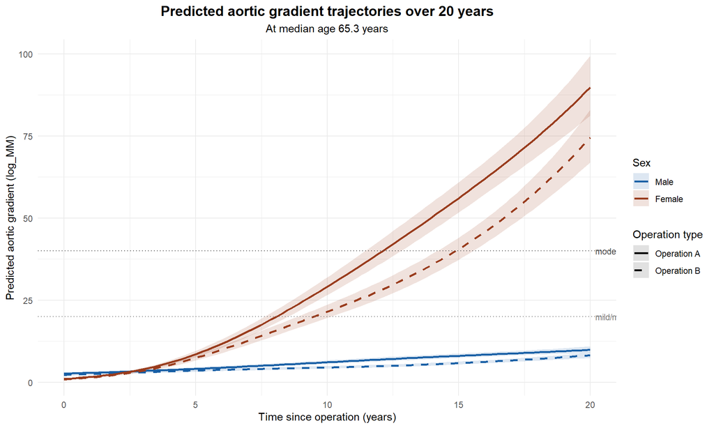

```r
# Effect plot function (from course)
effectPlotData <- function(object, newdata, orig_data) {
    form <- formula(object)
    namesVars <- all.vars(form)
    betas <- if (!inherits(object, "lme")) coef(object) else fixef(object)
    V <- if (inherits(object, "geeglm")) object$geese$vbeta else vcov(object)
    orig_data <- orig_data[complete.cases(orig_data[namesVars]), ]
    Terms <- delete.response(terms(form))
    mfX <- model.frame(Terms, data = orig_data)
    Terms_new <- attr(mfX, "terms")
    mfX_new <- model.frame(Terms_new, newdata, xlev = .getXlevels(Terms, mfX))
    X <- model.matrix(Terms_new, mfX_new)
    pred <- c(X %*% betas)
    ses <- sqrt(diag(X %*% V %*% t(X)))
    newdata$pred <- pred
    newdata$low <- pred - 1.96 * ses
    newdata$upp <- pred + 1.96 * ses
    newdata
}

# Build prediction grid
# Use median age, vary time across full 20-year follow-up
# Cross all combinations of sex and TypeOp
newdata_effect <- expand.grid(
    time   = seq(0, 20, length.out = 100),
    TypeOp = c("A", "B"),
    sex    = c("male", "female"),
    Age    = median(DF$Age, na.rm = TRUE)
)

# Generate predicted values + 95% CI
plotData <- effectPlotData(fm_reduced, newdata_effect, DF)

# Back-transform from log scale to mmHg
plotData$pred_mmHg <- exp(plotData$pred)
plotData$low_mmHg  <- exp(plotData$low)
plotData$upp_mmHg  <- exp(plotData$upp)

# Plot — predicted aortic gradient over 20 years by sex and operation type
ggplot(plotData, aes(x = time, y = pred_mmHg,
                     colour = sex, fill = sex,
                     linetype = TypeOp)) +
    geom_ribbon(aes(ymin = low_mmHg, ymax = upp_mmHg),
                alpha = 0.15, colour = NA) +
    geom_line(linewidth = 1) +
    # Clinical severity reference lines
    geom_hline(yintercept = 20, linetype = "dotted",
               colour = "gray50", linewidth = 0.5) +
    geom_hline(yintercept = 40, linetype = "dotted",
               colour = "gray30", linewidth = 0.5) +
    annotate("text", x = 20.2, y = 20, label = "mild/moderate",
             hjust = 0, size = 3, colour = "gray50") +
    annotate("text", x = 20.2, y = 40, label = "moderate/severe",
             hjust = 0, size = 3, colour = "gray30") +
    scale_colour_manual(values = c("male" = "#185FA5", "female" = "#993C1D"),
                        labels = c("Male", "Female")) +
    scale_fill_manual(values = c("male" = "#185FA5", "female" = "#993C1D"),
                      labels = c("Male", "Female")) +
    scale_linetype_manual(values = c("A" = "solid", "B" = "dashed"),
                          labels = c("Operation A", "Operation B")) +
    scale_x_continuous(breaks = seq(0, 20, by = 5)) +
    coord_cartesian(xlim = c(0, 20)) +
    labs(
        x        = "Time since operation (years)",
        y        = "Predicted aortic gradient (log_MM)",
        colour   = "Sex",
        fill     = "Sex",
        linetype = "Operation type",
        title    = "Predicted aortic gradient trajectories over 20 years",
        subtitle = paste0("At median age ", round(median(DF$Age, na.rm = TRUE), 1), " years")
    ) +
    theme_minimal() +
    theme(
        plot.title    = element_text(hjust = 0.5, size = 14, face = "bold"),
        plot.subtitle = element_text(hjust = 0.5, size = 11),
        legend.position = "right"
    )
```

We now check whether the model assumptions are met by *inspecting the residuals*;

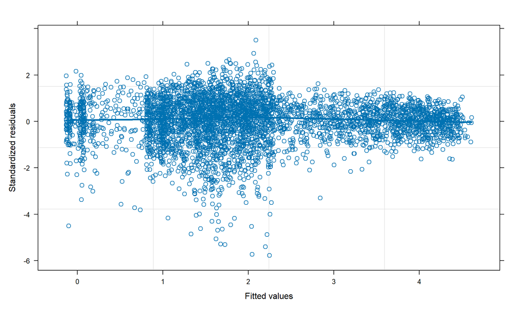

```r
# Starting with the standardized residuals - the overall scatteplot of these residuals versus the fitted values

plot(fm_reduced, resid(., type = "p") ~ fitted(.),
     type = c("p", "smooth"), lwd = 3)
```

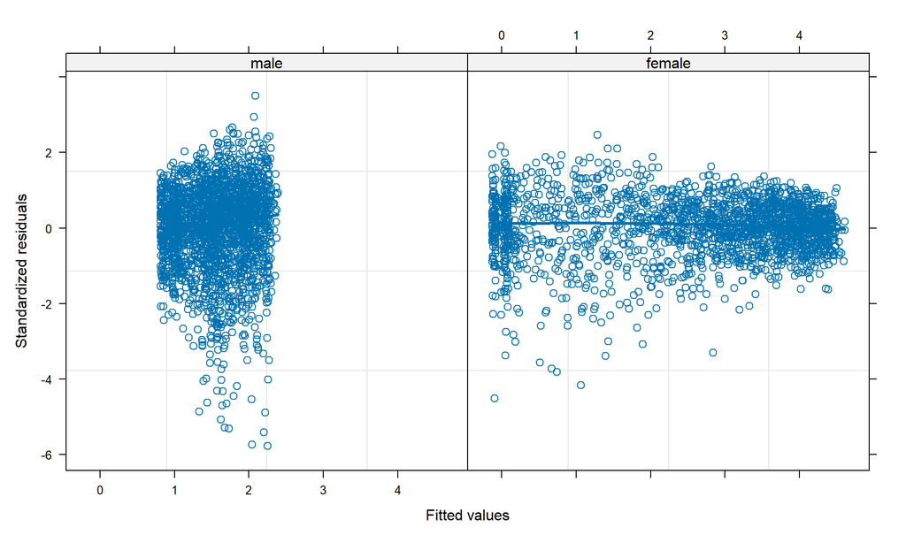

```r
# Then we split per sex and
plot(fm_reduced, resid(., type = "p") ~ fitted(.) | sex,
     type = c("p", "smooth"), lwd = 3)
```

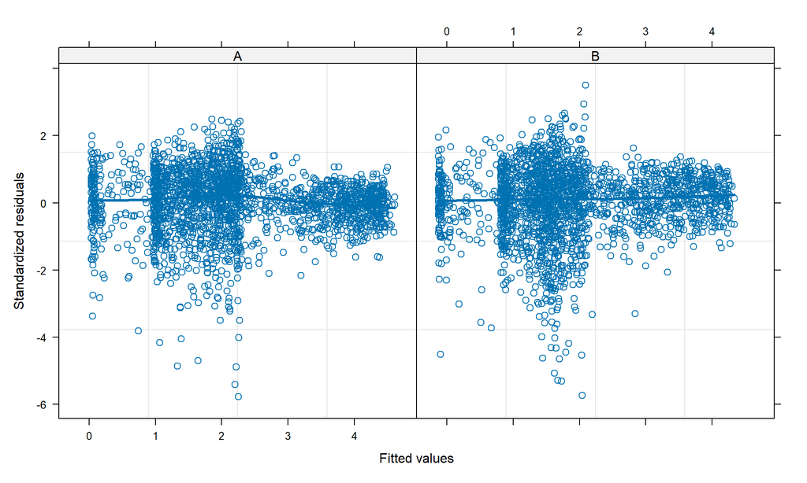

```r
# Then we split per operation type
plot(fm_reduced, resid(., type = "p") ~ fitted(.) | TypeOp,
     type = c("p", "smooth"), lwd = 3)
```

Looking at the normalized residuals:

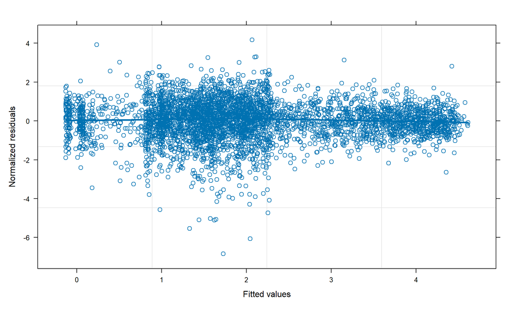

```r
# Continuing with the normalised residuals
plot(fm_reduced, resid(., type = "n") ~ fitted(.),
     type = c("p", "smooth"), lwd = 3)
```

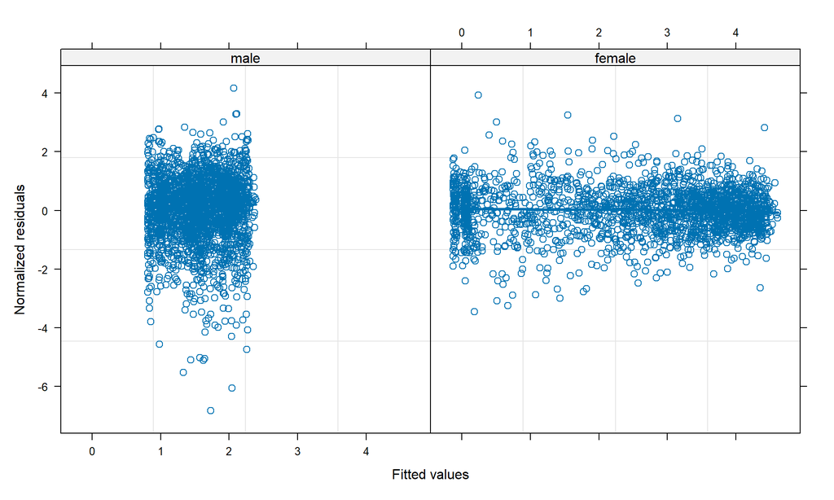

```r
# Then we split per sex and
plot(fm_reduced, resid(., type = "n") ~ fitted(.) | sex,
     type = c("p", "smooth"), lwd = 3)
```

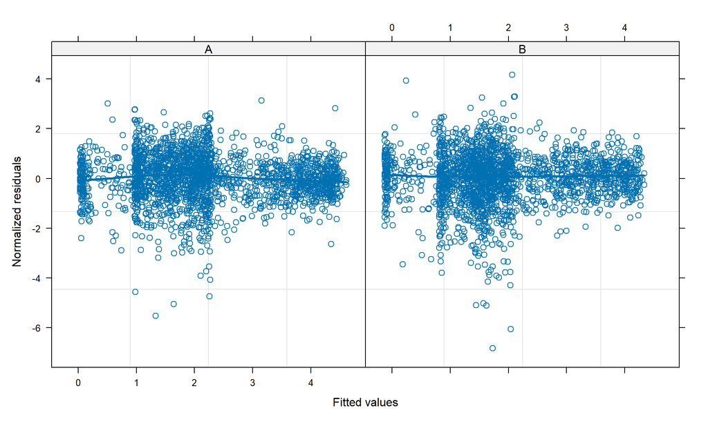

```r
# Then we split per operation type
plot(fm_reduced, resid(., type = "n") ~ fitted(.) | TypeOp,
     type = c("p", "smooth"), lwd = 3)
```

## Question 4:

Do exactly the same as in Question 3, but now using a linear mixed effects model.

### Step 1.

To fit the linear mixed effects model we use the function `lme()`. The basic call to this function requires specifying argument `fixed` which is a formula providing the fixed-effects structure, argument `random` which is a formula providing the random-effects structure, and `data` the data frame that contains the variables we need. Hence, the call to `lme()` to *fit the mixed model for aortic gradient* with

- fixed effects: the nonlinear effect of time using natural splines with 3 degrees of freedom, the main effects of TypeOp and sex, the nonlinear effect of age using natural cubic splines with 3 degrees of freedom, the interactions of time with TypeOp and sex, and age with TypeOp and sex, and
- random effects: random intercepts

```r
lme0 <- lme(aoGrad_log ~ nsk(time, 3) * (TypeOp + sex) + ns(Age, 3) +
                 ns(Age, 3):(TypeOp + sex),
               data = DF,
               random = ~ 1 | id)
```

### Step 2. Random intercept only vs random intercept + slope

We start by *expanding the random-effects structure* while keeping the same fixed effects, in order to appropriately model the correlations in the repeated aortic gradient measurements. We start by including a random slope for linear random slopes; using `update()` to avoid re-specifying all arguments:

```r
lme1 <- update(lme0, random = ~ time | id)
anova(lme0, lme1)
```

```
##      Model df      AIC      BIC    logLik   Test  L.Ratio p-value
## lme0     1 23 8842.058 8988.972 -4398.029
## lme1     2 25 8659.650 8819.339 -4304.825 1 vs 2 186.4077  <.0001
```

We then continue by checking if we need *quadratic random slopes* terms.

```r
lme2 <- update(lme1, random = ~ time + I(time^2) | id)
anova(lme1, lme2)
```

```
##      Model df      AIC      BIC    logLik   Test  L.Ratio p-value
## lme1     1 25 8659.650 8819.339 -4304.825
## lme2     2 28 8419.662 8598.513 -4181.831 1 vs 2 245.9887  <.0001
```

*Observation quadratic random slopes:* The likelihood ratio test comparing the linear random slope model (lme1) to the model additionally including a quadratic random slope (lme2) again yields a highly significant result (L.Ratio = 245.99, df = 3, p < .0001), with AIC dropping substantially from 8659.65 to 8419.66 and BIC from 8819.34 to 8598.51. This indicates that not only do patients differ in their linear rate of change over time, but also in the curvature of their individual trajectories. The quadratic random slope is therefore retained in the model.

We then attempt to further expand the random effects structure by adding a *cubic random slope term*:

```r
#lme3 <- update(lme2, random = ~ time + I(time^2) + I(time^3) | id)
#anova(lme2, lme3)
```

*Observation cubic slopes:* The model with cubic random slopes failed to converge (nlminb convergence error code = 1: iteration limit reached without convergence). This is likely due to the excessive complexity of estimating the additional covariance parameters namely; the variance of the cubic slope and its three covariances with the intercept, linear, and quadratic slopes, in combination with the unbalanced and irregular measurement structure of the data. We therefore retain the quadratic random slope model (lme2) as our final random effects structure and proceed to select the optimal correlation and variance structures.

### Step 3. Fixed-effects structure

Having chosen the random-effects structure (quadratic random slopes) we turn now to the fixed effects. We will first test whether the interaction terms have an important contribution in the fit of the model. To assess these changes we will use likelihood ratio tests. To perform a likelihood ratio test we need to fit the model under maximum likelihood (and not the restricted maximum likelihood-the default in lme()). Thus, in the following piece of code we first re-fit model lme2 using maximum likelihood and then we fit the model that excludes the interaction terms.

```r
# Model with ML
lme2_ML <- update(lme2, method = "ML")

# Modelt with ML but no interaction terms
lme2_ML_noInt <- lme(aoGrad_log ~ nsk(time, 3) + (TypeOp + sex) + ns(Age, 3),
               data = DF,
               random = ~ time + I(time^2) | id,
               method = "ML")

anova(lme2_ML,lme2_ML_noInt)
```

```
##               Model df      AIC      BIC    logLik   Test  L.Ratio p-value
## lme2_ML           1 28 8349.881 8528.866 -4146.940
## lme2_ML_noInt     2 16 9080.543 9182.820 -4524.271 1 vs 2 754.6619  <.0001
```

*Observation of dropping all interaction effect:* The likelihood ratio test comparing the full model with all interaction terms to the model without any interactions yields a likehood of 754.6619, P<.0001.

This means that the interaction terms jointly contribute significantly to model fit and cannot all be dropped simultaneously. We therefore proceed by testing each set of interactions separately to identify which are driving this result.

This means we will have to look at the interaction effect separately, starting with the *time interaction* effects.

```r
# Dropping time effects
lme2_ML_time_drop <- lme(aoGrad_log ~ nsk(time, 3) + (TypeOp + sex) + ns(Age, 3) +
              ns(Age, 3):(TypeOp + sex),
              data = DF,
              random = ~ time + I(time^2) | id,
              method = "ML")

#Orgininal_LME2 <- lme(aoGrad_log ~ nsk(time, 3) * (TypeOp + sex) + ns(Age, 3) +
#              ns(Age, 3):(TypeOp + sex),
#              data = DF,
#              random = random = ~ time + I(time^2) | id,
#              method = "ML")

anova_lme_time <- anova(lme2_ML, lme2_ML_time_drop)
anova_lme_time
```

```
##                   Model df      AIC      BIC    logLik   Test  L.Ratio p-value
## lme2_ML               1 28 8349.881 8528.866 -4146.940
## lme2_ML_time_drop     2 22 9088.331 9228.962 -4522.166 1 vs 2 750.4501  <.0001
```

*Observation of time effect test:* The likelihood ratio test comparing the full model (lme2_ML) with the reduced model without time interactions yields a test statistic with p < .0001, indicating that the time interactions contribute significantly to the model. Therefore, the interactions between the time effect and both sex and type of operation must be retained.

```r
lme2_age_drop <- lme(aoGrad_log ~ nsk(time, 3) * (TypeOp + sex) + ns(Age, 3),
              data = DF,
              random = ~ time + I(time^2) | id,
              method = "ML")

anova_lme_age <- anova(lme2_ML, lme2_age_drop)
anova_lme_age
```

```
##               Model df      AIC      BIC    logLik   Test  L.Ratio p-value
## lme2_ML           1 28 8349.881 8528.866 -4146.940
## lme2_age_drop     2 22 8342.409 8483.040 -4149.205 1 vs 2 4.528307  0.6056
```

*Observation of age test:* The likelihood ratio test showed no evidence that the age interactions contributed meaningfully (p = 0.6056). Therefore, the age interaction terms were removed from the final mean structure.

So the new model including quadratic random slopes and no interaction for age looks like this:

```r
lme_reduced <-lme(aoGrad_log ~ nsk(time, 3) * (TypeOp + sex) + ns(Age, 3),
              data = DF,
              random = ~ time + I(time^2) | id,
              method = "ML")
```

We then look at the linearity of time and wether non-linear time effect terms are needed in our model. To evaluate whether the evolution of the aortic gradient over time required a ***non‑linear specification**, we compared the model using a restricted cubic spline for time with an otherwise identical model using simple linear time terms for both follow-up time and age.

```r
lme_time_linear <- lme(aoGrad_log ~ time * (TypeOp + sex) + Age,
              data = DF,
              random = ~ time + I(time^2) | id,
              method = "ML")

anova_lme_time_linearity <- anova(lme_reduced, lme_time_linear)
anova_lme_time_linearity
```

```
##                 Model df      AIC      BIC    logLik   Test  L.Ratio p-value
## lme_reduced         1 22 8342.409 8483.040 -4149.205
## lme_time_linear     2 14 8733.971 8823.464 -4352.986 1 vs 2 407.5621  <.0001
```

*Observation non-linear vs. linear time:* Both models were fitted using maximum likelihood (ML) because they differed in fixed‑effect structure. The linear model showed a substantial deterioration in fit (p < 0.0001), indicating that a linear trajectory could not adequately capture the observed patterns.

To test if this is only for follow-up time or also for age, we measure again for non-linearity by comparing the age in splines vs. no splines.

```r
lme_age_linear<- lme(aoGrad_log ~ nsk(time, 3) * (TypeOp + sex) + Age,
              data = DF,
              random = ~ time + I(time^2) | id,
              method = "ML")

anova_lme_age_linearity <- anova(lme_reduced, lme_age_linear)
anova_lme_age_linearity
```

```
##                Model df      AIC      BIC    logLik   Test  L.Ratio p-value
## lme_reduced        1 22 8342.409 8483.040 -4149.205
## lme_age_linear     2 20 8339.877 8467.723 -4149.939 1 vs 2 1.467977    0.48
```

*Observation non-linear vs. linear age:* The linear model showed there was no substantial difference in fit (p = 0.48), indicating that a linear age trajectory can adequately capture the observed patterns and therefor does not need any non-linear specification. We therefore retained the non‑linear spline representation of time but removed the non-linear representation of age.

After establishing that time required a non‑linear form, we assessed whether a *simpler spline* (2 degrees of freedom) could replace the 3‑df spline used in the full model.

```r
lme_time_spline2 <- lme(aoGrad_log ~ nsk(time, 2) * (TypeOp + sex) + Age,
              data = DF,
              random = ~ time + I(time^2) | id,
              method = "ML")

anova_lme_knots <- anova(lme_age_linear, lme_time_spline2)
anova_lme_knots
```

```
##                  Model df      AIC      BIC    logLik   Test  L.Ratio p-value
## lme_age_linear       1 20 8339.877 8467.723 -4149.939
## lme_time_spline2     2 17 8387.250 8495.919 -4176.625 1 vs 2 53.37267  <.0001
```

*Observation reduction of spline knots:* Reducing the spline flexibility led to a significantly poorer fit ( p < 0.0001), demonstrating that the additional curvature captured by the 3‑df spline was necessary. The 3‑df spline was therefore retained and the final model was lme_age_linear.

*Conclusion model reduction* Based on the model‑reduction procedure, the interaction terms involving the non‑linear time effect were retained, whereas the interactions between age and the categorical variables (sex and type of operation) were removed. The final mean structure therefore includes a non‑linear effect of time, a linear effect of age, main effects of sex and type of operation, and interactions between time and both sex and type of operation, but no interactions involving age.

### Step 4. Interpretation and residual testing

```r
summary(lme_age_linear)
```

```
## Linear mixed-effects model fit by maximum likelihood
##   Data: DF
##        AIC      BIC    logLik
##   8339.877 8467.723 -4149.939
##
## Random effects:
##  Formula: ~time + I(time^2) | id
##  Structure: General positive-definite, Log-Cholesky parametrization
##             StdDev     Corr
## (Intercept) 0.66491788 (Intr) time
## time        0.12500742 -0.526
## I(time^2)   0.00592174  0.336 -0.970
## Residual    0.51465392
##
## Fixed effects:  aoGrad_log ~ nsk(time, 3) * (TypeOp + sex) + Age
##                              Value  Std.Error   DF   t-value p-value
## (Intercept)              0.8699405 0.11263446 3904   7.72357  0.0000
## nsk(time, 3)1            0.4196894 0.05769270 3904   7.27457  0.0000
## nsk(time, 3)2            0.9607710 0.06937403 3904  13.84914  0.0000
## nsk(time, 3)3            1.2704467 0.07041858 3904  18.04136  0.0000
## TypeOpB                 -0.1515739 0.07098435  496  -2.13531  0.0332
## sexfemale               -0.9108283 0.07100255  496 -12.82811  0.0000
## Age                      0.0019307 0.00146969  496   1.31366  0.1896
## nsk(time, 3)1:TypeOpB    0.0222068 0.06729493 3904   0.32999  0.7414
## nsk(time, 3)2:TypeOpB   -0.1915688 0.08020137 3904  -2.38860  0.0170
## nsk(time, 3)3:TypeOpB   -0.0755256 0.08161796 3904  -0.92535  0.3548
## nsk(time, 3)1:sexfemale  1.5771748 0.06735115 3904  23.41719  0.0000
## nsk(time, 3)2:sexfemale  2.6181867 0.08025390 3904  32.62380  0.0000
## nsk(time, 3)3:sexfemale  3.0474381 0.08156506 3904  37.36205  0.0000
##  Correlation:
##                         (Intr) ns(,3)1 ns(,3)2 ns(,3)3 TypOpB sexfml Age
## nsk(time, 3)1           -0.338
## nsk(time, 3)2           -0.389  0.718
## nsk(time, 3)3           -0.415  0.607   0.607
## TypeOpB                 -0.305  0.372   0.426   0.463
## sexfemale               -0.336  0.361   0.415   0.452   0.045
## Age                     -0.837 -0.001   0.000  -0.010  -0.028  0.020
## nsk(time, 3)1:TypeOpB    0.201 -0.589  -0.425  -0.358  -0.619 -0.023  0.000
## nsk(time, 3)2:TypeOpB    0.232 -0.429  -0.597  -0.361  -0.710 -0.030  0.001
## nsk(time, 3)3:TypeOpB    0.245 -0.360  -0.360  -0.590  -0.769 -0.035  0.008
```

[output cut: 8 more lines]

```
## sexfemale
## Age
## nsk(time, 3)1:TypeOpB
## nsk(time, 3)2:TypeOpB    0.713
## nsk(time, 3)3:TypeOpB    0.605    0.596
## nsk(time, 3)1:sexfemale  0.017    0.025    0.022
## nsk(time, 3)2:sexfemale  0.025    0.042    0.024    0.713
## nsk(time, 3)3:sexfemale  0.022    0.025    0.049    0.605    0.597
##
## Standardized Within-Group Residuals:
##         Min          Q1         Med          Q3         Max
## -5.67583757 -0.42979334  0.06116402  0.53077658  3.17073886
##
## Number of Observations: 4413
## Number of Groups: 500
```

*Interpretation of output:* The interpretation of the regression coefficients is as follows:

The coefficients that involve the polynomial terms of time do not have a straightforward interpretation, this will require the effect plot following later.

The coefficients of TypeOp, sex and Age are interpreted as followed:

-0.15 is the expected difference in the log transformed aortic gradient between people that recieved operation B vs. operation A, when they are the same age and sex, and who are compared at the same follow-up time.

-0.91 is the expected difference in log transformed aortic gradient between females and males, who receive the same operation and are of the same age, and who are compared at the same follow-up time.

0.002 is the expected difference in aortic gradient for a unit increase in the baseline age for patients who have the same sex, underwent the same operation (either A or B, and who are compared at the same follow-up time.

### Comparing the margnal model vs. the random effects model:

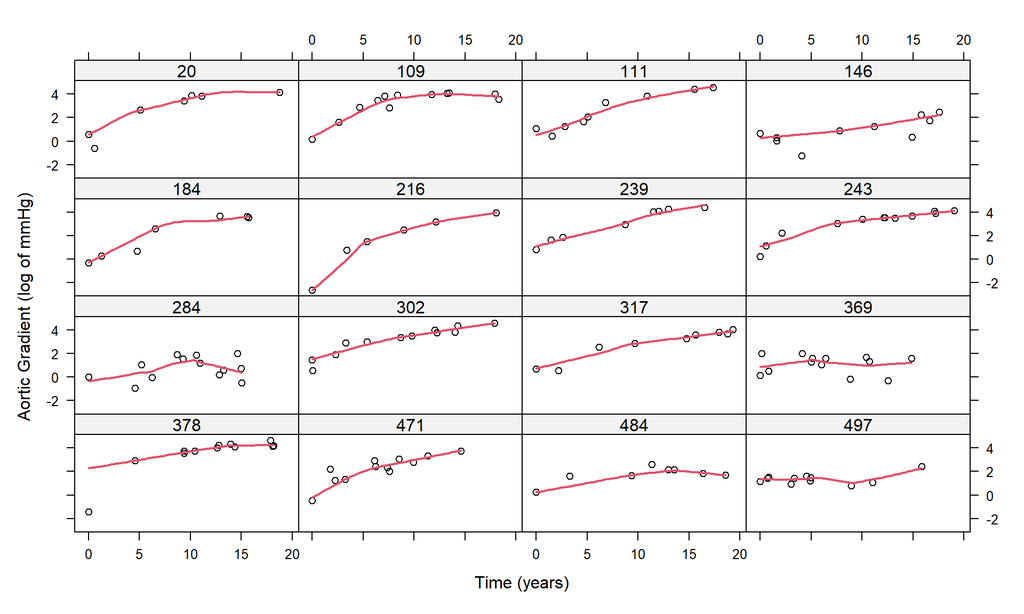

```r
# Adding fitted values for marginal and subject specific
DF$fitted_marg <- fitted(lme_age_linear, level = 0) # marginal
DF$fitted_subj <- fitted(lme_age_linear, level = 1) # subject-specific

# Extracting the number of repeated measurements per person id
length.no.NA <- function (x) sum(!is.na(x))
ns <- with(DF, tapply(aoGrad_log, id, length.no.NA))

# Subject specific trajector plot general (as in q2 from practical 2)
set.seed(123)
ids <- sample(names(ns)[ns >= 6], 16)
xyplot(aoGrad_log ~ time | id,
       panel = function (x, y, ...) {
           panel.xyplot(x, y, type = "p", col = 1, ...)
           panel.loess(x, y, col = 2, lwd = 2, span = 0.8)
       }, data = DF, subset = id %in% ids, layout = c(4, 4), as.table = TRUE,
       xlab = "Time (years)", ylab = "Aortic Gradient (log of mmHg)")
```

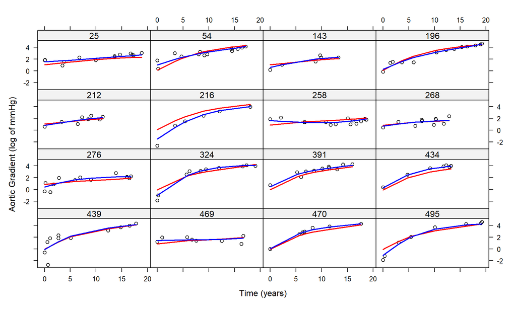

```r
# Now creating a plot using a similar call to function but with the fitted and marginal predictions?

ids <- c(25, 54, 143, 196, 212, 216, 258, 268, 276, 324, 391, 434, 439, 469, 470, 495)
xyplot(aoGrad_log + fitted_marg + fitted_subj ~ time | id, data = DF,
       panel = function (x, y, ...) {
           x.mat <- matrix(x, ncol = 3)
           y.mat <- matrix(y, ncol = 3)
           panel.xyplot(x.mat[, 1], y.mat[, 1], type = "p", col = "black")
           panel.xyplot(x.mat[, 2], y.mat[, 2], type = "l", lwd = 2, col = "red")
           panel.xyplot(x.mat[, 3], y.mat[, 3], type = "l", lwd = 2, col = "blue")
       }, subset = id %in% ids, layout = c(4, 4), as.table = TRUE,
       xlab = "Time (years)", ylab = "Aortic Gradient (log of mmHg)")
```

*Observation person plot;* it seems the difference between marginal and subject specific predictions are not that big. Where it seems the subject-specific fit a little bit better..?

### Effect plot

We re-use the effectPlotData function specified before. This function now takes our fitted mixed model, the data frame “newdata” based on which the plot will be made, and the original data we used to fit the model, and returns the predictions for each row of newdata with the corresponding lower and upper limits of the 95% confidence intervals.

```r
effectPlotData <- function (object, newdata, orig_data) {
    form <- formula(object)
    namesVars <- all.vars(form)
    betas <- if (!inherits(object, "lme")) coef(object) else fixef(object)
    V <- if (inherits(object, "geeglm")) object$geese$vbeta else vcov(object)
    orig_data <- orig_data[complete.cases(orig_data[namesVars]), ]
    Terms <- delete.response(terms(form))
    mfX <- model.frame(Terms, data = orig_data)
    Terms_new <- attr(mfX, "terms")
    mfX_new <- model.frame(Terms_new, newdata, xlev = .getXlevels(Terms, mfX))
    X <- model.matrix(Terms_new, mfX_new)
    pred <- c(X %*% betas)
    ses <- sqrt(diag(X %*% V %*% t(X)))
    newdata$pred <- pred
    newdata$low <- pred - 1.96 * ses
    newdata$upp <- pred + 1.96 * ses
    newdata
}
```

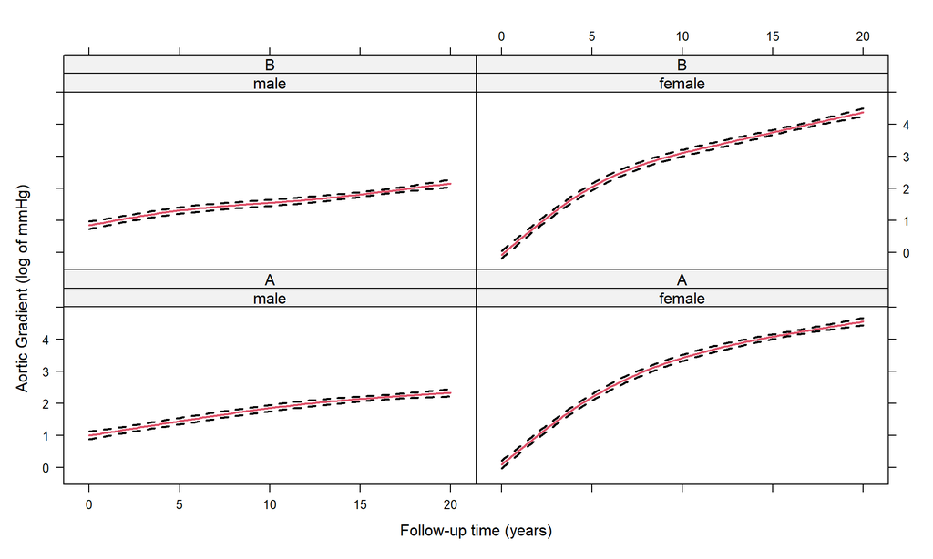

```r
newDF <- with(DF, expand.grid(time = seq(0, 20, length.out = 100),
                                sex = levels(sex), TypeOp = levels(TypeOp)))


# Setting net DF ascpects for effectplot
DF.id <- DF[!duplicated(DF$id), ]
median_age <- with(DF.id, tapply(Age, list(sex, TypeOp), median))
ns <- with(newDF, tapply(time, list(sex, TypeOp), length))
newDF$Age <- rep(c(median_age), c(ns))


# Actual plot
xyplot(pred + low + upp ~ time | sex * TypeOp,
       data = effectPlotData(lme_age_linear, newDF, DF),
       lty = c(1, 2, 2), col = c(2, 1, 1), lwd = 2, type = "l",
       xlab = "Follow-up time (years)",
       ylab = "Aortic Gradient (log of mmHg)")
```

Trying to put it all together again:

[figure not shown]

```r
# Build prediction grid
# Use median age, vary time across full 20-year follow-up
# Cross all combinations of sex and TypeOp
newdata_effect <- expand.grid(
    time   = seq(0, 20, length.out = 100),
    TypeOp = c("A", "B"),
    sex    = c("male", "female"),
    Age    = median(DF$Age, na.rm = TRUE)
)

# Generate predicted values + 95% CI
plotData <- effectPlotData(lme_age_linear, newdata_effect, DF)

# Back-transform from log scale to mmHg
plotData$pred_mmHg <- exp(plotData$pred)
plotData$low_mmHg  <- exp(plotData$low)
plotData$upp_mmHg  <- exp(plotData$upp)

# Plot — predicted aortic gradient over 20 years by sex and operation type
ggplot(plotData, aes(x = time, y = pred_mmHg,
                     colour = sex, fill = sex,
                     linetype = TypeOp)) +
    geom_ribbon(aes(ymin = low_mmHg, ymax = upp_mmHg),
                alpha = 0.15, colour = NA) +
    geom_line(linewidth = 1) +
    # Clinical severity reference lines
    geom_hline(yintercept = 20, linetype = "dotted",
               colour = "gray50", linewidth = 0.5) +
    geom_hline(yintercept = 40, linetype = "dotted",
               colour = "gray30", linewidth = 0.5) +
    annotate("text", x = 20.2, y = 20, label = "mild/moderate",
             hjust = 0, size = 3, colour = "gray50") +
    annotate("text", x = 20.2, y = 40, label = "moderate/severe",
             hjust = 0, size = 3, colour = "gray30") +
    scale_colour_manual(values = c("male" = "#185FA5", "female" = "#993C1D"),
                        labels = c("Male", "Female")) +
    scale_fill_manual(values = c("male" = "#185FA5", "female" = "#993C1D"),
                      labels = c("Male", "Female")) +
    scale_linetype_manual(values = c("A" = "solid", "B" = "dashed"),
                          labels = c("Operation A", "Operation B")) +
    scale_x_continuous(breaks = seq(0, 20, by = 5)) +
    coord_cartesian(xlim = c(0, 20)) +
    labs(
        x        = "Time since operation (years)",
        y        = "Predicted aortic gradient (log_MM)",
        colour   = "Sex",
        fill     = "Sex",
        linetype = "Operation type",
        title    = "Predicted aortic gradient trajectories over 20 years",
        subtitle = paste0("At median age ", round(median(DF$Age, na.rm = TRUE), 1), " years")
    ) +
    theme_minimal() +
    theme(
        plot.title    = element_text(hjust = 0.5, size = 14, face = "bold"),
        plot.subtitle = element_text(hjust = 0.5, size = 11),
        legend.position = "right"
    )
```

*Observation effect plot* Identical to first one when fitting marignal model no?

We now check whether the model assumptions are met by *inspecting the residuals*;

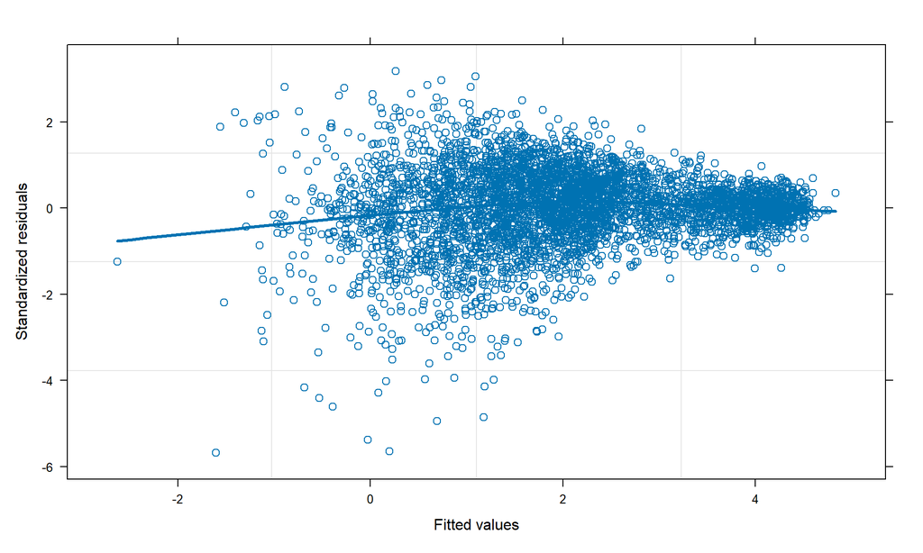

```r
# Starting with the standardized residuals - the overall scatterplot of these residuals versus the fitted values

plot(lme_age_linear, resid(., type = "p") ~ fitted(.),
     type = c("p", "smooth"), lwd = 3)
```

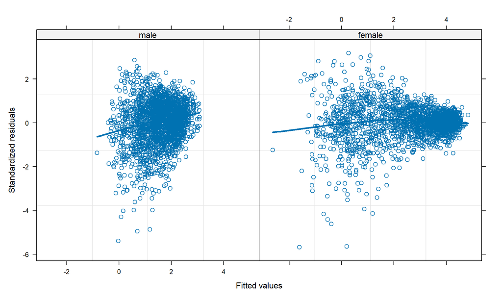

```r
# Then we split per sex and
plot(lme_age_linear, resid(., type = "p") ~ fitted(.) | sex,
     type = c("p", "smooth"), lwd = 3)
```

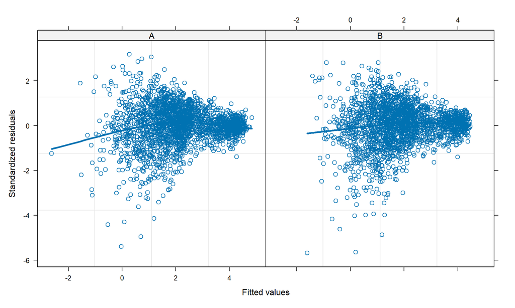

```r
# Then we split per operation type
plot(lme_age_linear, resid(., type = "p") ~ fitted(.) | TypeOp,
     type = c("p", "smooth"), lwd = 3)
```

*Observation residuals standardised:* Already seems better compared to marginal model!

Looking at the normalized residuals:

[figure not shown]

```r
# Continuing with the normalised residuals
plot(lme_age_linear, resid(., type = "n") ~ fitted(.),
     type = c("p", "smooth"), lwd = 3)
```

[figure not shown]

```r
# Then we split per sex and
plot(lme_age_linear, resid(., type = "n") ~ fitted(.) | sex,
     type = c("p", "smooth"), lwd = 3)
```

[figure not shown]

```r
# Then we split per operation type
plot(lme_age_linear, resid(., type = "n") ~ fitted(.) | TypeOp,
     type = c("p", "smooth"), lwd = 3)
```

## Question 5: Which of your two final models in Questions 3 and 4 would you choose as your final model for aortic gradient?

No idea… My guess would be the mixed effects as there seems to be a random effect as well even though the very clear conclusion is that women are much worse off in this data? ——————————-part 2 of exam ———————————-

# Part 2 of exam (categorical data) - Aortic Regurgitation

The focus is on the aortic regurgitation outcome.

## Question 6.

### Produce descriptive figures for this outcome and graphically depict the longitudinal evolutions (both marginal and subject-specific).

### Discuss the results you obtain.

*Main Analysis* The researchers in this study are interested in investigating how the probability of aortic regurgitation evolves over time and how this evolution is related to the rest of the variables in the database (namely, age, sex, and type of operation).

## Question 7.

## Question 8

Do exactly the same as in Question 7, but now using a mixed effects logistic regression model.

## Questin 9

9. Which of your two final models in Questions 7 and 8 would you choose as your final model for aortic regurgitation? Would your answer change if the researchers in this study were primarily interested in predictions (i.e., building a model that best predicts aortic regurgitation)?